# Test for Variance

Chi square and F tests

Ranadeep Daw

2024-09-12

## One sample Variance Test

- **Data**: $x_1, x_2, \ldots, x_n$.
- **Assumptions**: $X \sim \mathbb{N}(\mu, \sigma^2)$.
- $H_0: \sigma^2 = \sigma_0^2$ vs $H_A: \sigma^2 \neq, \leq, \geq \sigma_0^2$.
- Sample variance: $s^2 = \frac{1}{n-1} \sum_{i=1}^{n} (x_i - \bar{x})^2$.

## Procedure

- Test statistic: $T = \frac{(n-1) s^2}{ \sigma_0^2}$
- Reject $H_0$ if:
  - $T < \chi^2_{\alpha, n-1}$ if $H_A: \sigma^2 < \sigma_0^2$.
  - $T > \chi^2_{1-\alpha, n-1}$ if $H_A: \sigma^2 > \sigma_0^2$.
  - $T > \chi^2_{1-\alpha/2, n-1}$ and $T < \chi^2_{\alpha/2, n-1}$ if $H_A: \sigma^2 \neq \sigma_0^2$.

## Graphical Representation

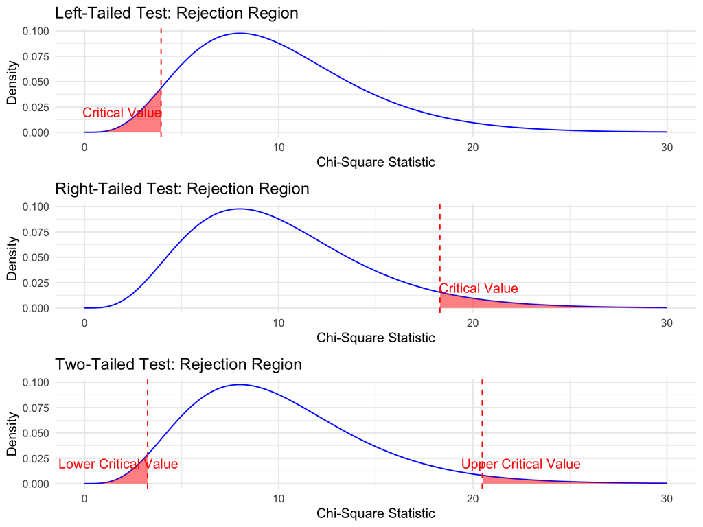

## Example for $\texttt{mpg}$ from $\texttt{mtcars}$

- You will need to install the package $\texttt{EnvStats}$.

```r
install.packages("EnvStats")
```

- Let’s do the test if variance of mpg is = 36 against less than 36.
- Syntax:

```r
varTest(x, alternative = "two.sided/less/greater", conf.level = ...,
    sigma.squared = <value_of_the_hypotheses>)
```

## Example

```r
library("EnvStats")
data("mtcars")
MPG = mtcars$mpg
varTest(MPG, alternative = "less", conf.level = 0.95,  sigma.squared = 36, data.name = NULL)
```

```
##
## Results of Hypothesis Test
## --------------------------
##
## Null Hypothesis:                 variance = 36
##
## Alternative Hypothesis:          True variance is less than 36
##
## Test Name:                       Chi-Squared Test on Variance
##
## Estimated Parameter(s):          variance = 36.3241
##
## Data:                            MPG
##
## Test Statistic:                  Chi-Squared = 31.27909
##
## Test Statistic Parameter:        df = 31
##
## P-value:                         0.5477861
##
## 95% Confidence Interval:         LCL =  0.00000
##                                  UCL = 58.40321
```

## Two-sample equality of variance

- Data:
  - $\mathbb{X}_1: \{x_{11}, x_{12}, \ldots, x_{1m} \}$
  - $\mathbb{X}_2: \{x_{21}, x_{22}, \ldots, x_{2n} \}$
- Assumption: $\mathbb{X}_1 \sim \mathbb{N}(\mu_1, \sigma^2_1)$, $\mathbb{X}_2 \sim \mathbb{N}(\mu_2, \sigma^2_2)$.
- Hypotheses: $H_0: \sigma_1^2 = \sigma_2^2$ vs $H_A: \sigma_1^2 \leq, \neq, \geq \sigma_2^2$.

## Procedure

- **Test Statistic:** $F = \frac{s_1^2}{s_2^2}$; where $s_1^2$ and $s_2^2$ are the sample variances.
- Reject if:
  - $F < F_{\alpha, m-1, n-1}$ if $H_A: \sigma_1^2 < \sigma_2^2$.
  - $F > F_{1-\alpha, m-1, n-1}$ if $H_A: \sigma_1^2 > \sigma_2^2$.
  - $F > F_{1-\alpha/2, m-1, n-1}$ or $F < F_{\alpha/2, m-1, n-1}$ if two sided test.

## $\texttt{R}$ Syntax

- Let’s test if there is a difference in the variances of $\texttt{mpg}$ in the $\texttt{mtcars}$ data based on the transmission (Variable = $\texttt{am}$).
- Syntax:

```r
var.test(<var1> ~ <var2>,
         alternative = "two.sided / less / greater",
         conf.level = ...)
```

## Example

```r
data("mtcars")
MPG = mtcars$mpg
Automatic = mtcars$am
var.test(MPG ~ Automatic, alternative = "two.sided", conf.level = 0.95)
```

```
##
##  F test to compare two variances
##
## data:  MPG by Automatic
## F = 0.38656, num df = 18, denom df = 12, p-value = 0.06691
## alternative hypothesis: true ratio of variances is not equal to 1
## 95 percent confidence interval:
##  0.1243721 1.0703429
## sample estimates:
## ratio of variances
##          0.3865615
```

## Graphical Representation

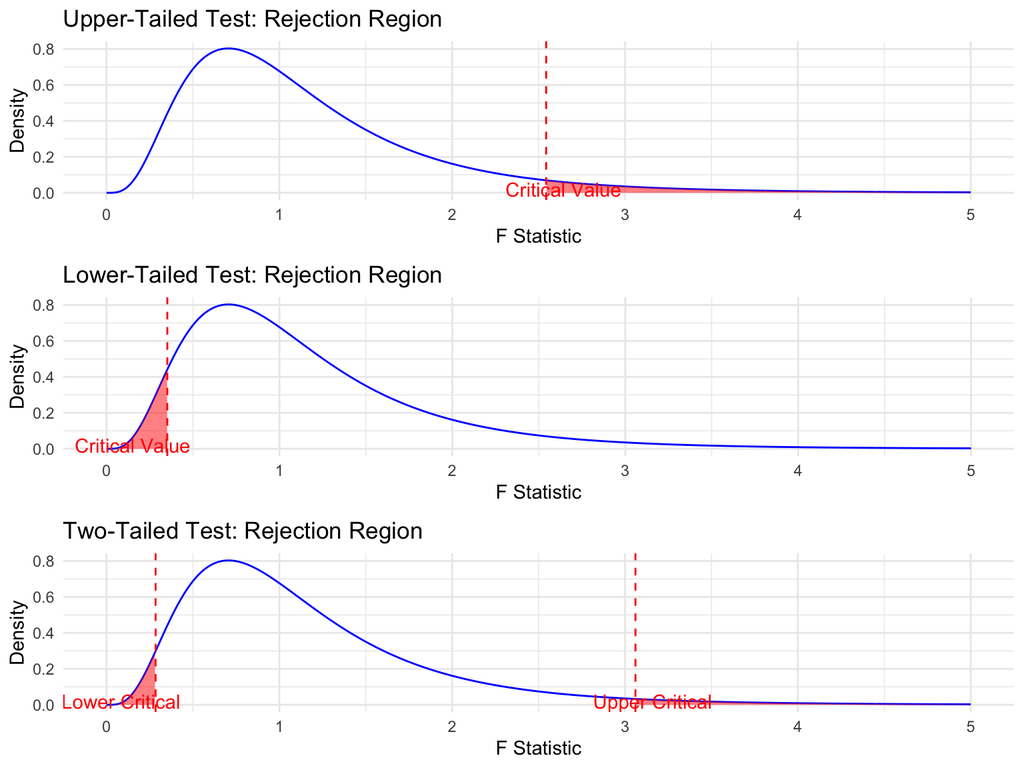